# tensorflowEx

TensorFlow 簡易初談

[figure not shown]

Abstract

Tensorflow 官網:https://www.tensorflow.org/api_guides/python/train  
知識補充包：https://www.slideshare.net/ckmarkohchang/tensorflow-61523042?next_slideshow=1  
懶人影片包：  
https://www.youtube.com/watch?v=lAaCeiqE6CE&list=PLXO45tsB95cKI5AIlf5TxxFPzb-0zeVZ8  
https://www.youtube.com/watch?v=u4alGiomYP4&feature=share  
Tensorflow中文社區（簡體）：http://www.tensorfly.cn/

Why tensorflow?

- TensorFlow is more of a low-level library.
- Deep Flexibility.
- Take advantage of GPUs for more efficient training.
- The result of Deep learning would better than machine learing.
- Maximize Performanc.

參考資料：  
[What is the main difference between TensorFlow and scikit-learn?](https://sebastianraschka.com/faq/docs/tensorflow-vs-scikitlearn.html)  
[Deep Learning Frameworks Compared](https://www.youtube.com/watch?v=MDP9FfsNx60)  
[盤點四大民間機器學習開源框架：Theano、Caffe、Torch 和 SciKit-learn](https://read01.com/nJnKnJ.html#.WXWsvdOGOog)  
[谷歌：為何從Scikit-learn轉向TensorFlow](https://kknews.cc/tech/nx5pek2.html)

基本結構 tensor

- 建立graph來進行計算
- tf.Session()
- tf.Variable()
- tf.placeholder()

[figure not shown]

# tf.Session()

```python
#簡單的相乘
#類似於spark不會真的被執行直到action
import tensorflow as tf

matrix1 = tf.constant([[3, 3]])
matrix2 = tf.constant([[2],
                       [2]])
print matrix1
print matrix2
```

```
Tensor("Const_96:0", shape=(1, 2), dtype=int32)
Tensor("Const_97:0", shape=(2, 1), dtype=int32)
```

```python
product = tf.matmul(matrix1, matrix2)  # matrix multiply np.dot(m1, m2)
print product
```

```
Tensor("MatMul_53:0", shape=(1, 1), dtype=int32)
```

```python
#show constant
#sess.run()才真正的執行
sess = tf.Session()
resultmatrix1 = sess.run(matrix1)
print resultmatrix1
```

```
[[3 3]]
```

```python
# method 1
sess = tf.Session()
result = sess.run(product)
print(result)
sess.close()

# method 2
with tf.Session() as sess:
    result2 = sess.run(product)
    print(result2)
```

[output not shown]

# tf.Variable()

```python
# 一定要
# init = tf.global_variables_initializer()
# sess.run(init)

#簡單的相加 assign給某變數
import tensorflow as tf

state = tf.Variable(0, name='counter')
print(state.name)
one = tf.constant(1)

new_value = tf.add(state, one)
update = tf.assign(state, new_value)
#只有要使用到Variable 一定要先初始
init = tf.global_variables_initializer()

with tf.Session() as sess:
    sess.run(init)
    for _ in range(3):
        sess.run(update)
        print(sess.run(state))
```

```
counter_13:0
1
2
3
```

# tf.placeholder() ＆ feed_dict

```python
import tensorflow as tf

input1 = tf.placeholder(tf.float32)
input2 = tf.placeholder(tf.float32)
ouput = tf.multiply(input1, input2)

with tf.Session() as sess:
    print(sess.run(ouput, feed_dict={input1: [6.], input2: [2.]}))
```

```
[ 12.]
```

簡易小範例

$y = 0.1x + 0.3$

```python
#-*- coding: utf-8 -*-
import tensorflow as tf
import numpy as np

# creat data
#創造 亂數100個亂數 值介於0~1之間
x_data = np.random.rand(100).astype(np.float32)

#訂出要學習的函數  這裡要學的是 weight:0.1  biases:0.3
y_data = x_data*0.1+0.3
# y = ax + b

# print x_data
# print y_data
```

```python
###creat tensorflow structure start###
#定立 weights 的 範圍 和初始化
Weights = tf.Variable(tf.random_uniform([1],-1.0,1.0))
biases = tf.Variable(tf.zeros([1]))

#定立 給 tensorflow 學習的函數
y = Weights*x_data + biases

#建立 loss 規則
loss = tf.reduce_mean(tf.square(y-y_data))

#選擇學習機制
optimizer = tf.train.GradientDescentOptimizer(0.5)  #learning rate

#像tensorflow 說 訓練規則就是把 loss 減到最小 最好是0
train = optimizer.minimize(loss)

#初始化所有變數
init = tf.global_variables_initializer()

###creat tensorflow structure end###
```

```python
#*****************************************************開始訓練
#建立sess
sess = tf.Session()

#記得初始化
sess.run(init)     #Very important

"""
跑 for 迴圈 更新wight201次
然後每訓練20次 印出一次weight
"""
for step in range(201):
    sess.run(train)
    if step % 20 ==0:
        print(step,sess.run(Weights),sess.run(biases),sess.run(loss))
```

```
(0, array([-0.27908954], dtype=float32), array([ 0.74445444], dtype=float32), 0.075000979)
(20, array([ 0.00213873], dtype=float32), array([ 0.35528499], dtype=float32), 0.00096281094)
(40, array([ 0.07995282], dtype=float32), array([ 0.31132531], dtype=float32), 4.0404153e-05)
(60, array([ 0.09589328], dtype=float32), array([ 0.30232003], dtype=float32), 1.6955497e-06)
(80, array([ 0.09915872], dtype=float32), array([ 0.30047527], dtype=float32), 7.115419e-08)
(100, array([ 0.09982767], dtype=float32), array([ 0.30009738], dtype=float32), 2.9859166e-09)
(120, array([ 0.09996471], dtype=float32), array([ 0.30001995], dtype=float32), 1.252318e-10)
(140, array([ 0.09999277], dtype=float32), array([ 0.30000409], dtype=float32), 5.2501736e-12)
(160, array([ 0.09999851], dtype=float32), array([ 0.30000085], dtype=float32), 2.2172486e-13)
(180, array([ 0.0999997], dtype=float32), array([ 0.30000019], dtype=float32), 9.903189e-15)
(200, array([ 0.09999991], dtype=float32), array([ 0.30000007], dtype=float32), 1.1990409e-15)
```

Optimizer & Learning Rate

Optimizer種類：https://www.tensorflow.org/api_guides/python/train  
CNN相關介紹（loss, optimization）:http://cs231n.github.io/neural-networks-3/

- tf.train.Optimizer
- tf.train.GradientDescentOptimizer
- tf.train.AdadeltaOptimizer
- tf.train.MomentumOptimizer
- tf.train.AdamOptimizer
- tf.train.RMSPropOptimizer
- ...

目的是最小化loss function  
嘗試要最小化這些loss or cost，當這些成本或損失越低的時候，就代表著我們的模型越好

[figure not shown]

Activation functions

激活函數都有哪些?有哪些優缺點?  
https://www.tensorflow.org/versions/r0.12/api_docs/python/nn/

怎麼選用激活函數?  
http://mropengate.blogspot.tw/2017/02/deep-learning-role-of-activation.html

- tf.nn.relu
- tf.nn.relu6
- tf.nn.crelu
- tf.nn.elu
- tf.nn.softplus
- tf.nn.softsign
- tf.nn.dropout
- tf.nn.bias_add
- tf.sigmoid
- tf.tanh

處理不能用線性處理的非線性問題，讓線性方程式轉成非線性方程式（https://www.youtube.com/watch?v=tI9AbaBfnPc&list=PLXO45tsB95cKI5AIlf5TxxFPzb-0zeVZ8&index=11）

可用線性表達

[figure not shown]

不可用線性表達

[figure not shown]

# Sigmoid 取值[0,1] & tanh 取值[-1,1]

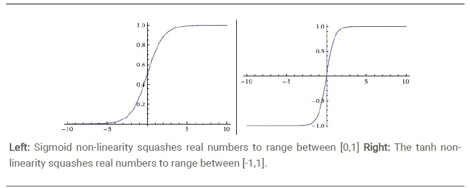

```python
from IPython.display import Image
Image(filename='/Users/gohuang/Pictures/activationFunction.jpg')
```

# Relu

$f(x)= max(0,x)$  
大於0的留下，否則一律為0

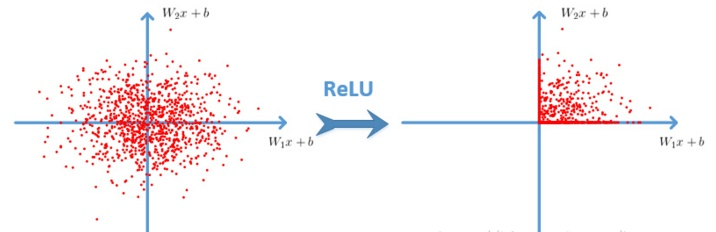

```python
from IPython.display import Image
Image(filename='/Users/gohuang/Pictures/activationFunction2.jpg')
```

NN example

$y = x^2 - 0.5$

[figure not shown]

EX: 一個輸入層、一個隱藏層（10個神經元）、一個輸出層

```python
import tensorflow as tf
import numpy as np

#建立隱藏層 輸入值、輸入層數、輸出層數、激勵函數
def add_layer(inputs, in_size, out_size, activation_function=None):
    # add one more layer and return the output of this layer
    Weights = tf.Variable(tf.random_normal([in_size, out_size]))
    biases = tf.Variable(tf.zeros([1, out_size]) + 0.1)
    #input乘上Weights 加上 biases
    Wx_plus_b = tf.matmul(inputs, Weights) + biases

    #定義激勵函數與否
    if activation_function is None:
        outputs = Wx_plus_b
    else:
        outputs = activation_function(Wx_plus_b)
    return outputs
```

建立隨機資料，加入noise

```python
# Make up some real data
x_data = np.linspace(-1,1,300)[:, np.newaxis]# 300 raw with one value 1:-1
noise = np.random.normal(0, 0.05, x_data.shape)# 呈現真實數據 非線性 標準差0.05 跟x_data相同格式
y_data = np.square(x_data) - 0.5 + noise

# print x_data
# print noise
# print y_data
```

```python
# define placeholder for inputs to network
xs = tf.placeholder(tf.float32, [None, 1])
ys = tf.placeholder(tf.float32, [None, 1])
```

建立輸入層、隱藏層、輸出層 1:relu:10:none:1

```python
#建立輸入層、隱藏層、輸出層
# add hidden layer
l1 = add_layer(xs, 1, 10, activation_function=tf.nn.relu)
# add output layer
prediction = add_layer(l1, 10, 1, activation_function=None)
```

```python
# 最小化Loss值
# the error between prediction and real data
loss = tf.reduce_mean(tf.reduce_sum(tf.square(ys - prediction),
                     reduction_indices=[1]))
train_step = tf.train.GradientDescentOptimizer(0.1).minimize(loss)
```

結果

```python
init = tf.global_variables_initializer()

sess = tf.Session()
sess.run(init)

for i in range(1000):
    # training
    sess.run(train_step, feed_dict={xs: x_data, ys: y_data})
    if i % 100 == 0:
        # to see the step improvement
        print(sess.run(loss, feed_dict={xs: x_data, ys: y_data}))
#         print(sess.run(prediction, feed_dict={xs: x_data, ys: y_data}))
```

```
0.505872
0.0108641
0.00709251
0.00630186
0.0056544
0.00510261
0.00459759
0.004199
0.00388177
0.00364146
```

NN example(visualization1)

$y = x^2 - 0.5$

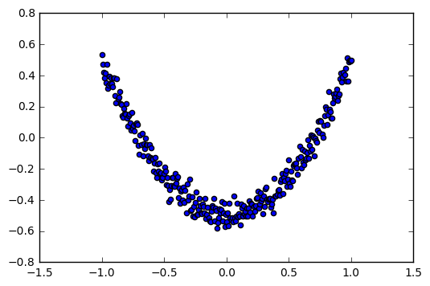

```
0.315596
0.0123119
0.00740093
0.00561084
0.00474124
0.00427327
0.00403562
0.00387777
0.0037502
0.00364036
0.00356692
0.00347957
0.00339744
0.00333398
0.00329147
0.00326289
0.00324011
0.00322277
0.0032093
0.00319723
```

```python
import tensorflow as tf
import numpy as np
import matplotlib.pyplot as plt

def add_layer(inputs, in_size, out_size, activation_function=None):
    # add one more layer and return the output of this layer
    Weights = tf.Variable(tf.random_normal([in_size, out_size]))
    biases = tf.Variable(tf.zeros([1, out_size]) + 0.1)
    Wx_plus_b = tf.matmul(inputs, Weights) + biases
    if activation_function is None:
        outputs = Wx_plus_b
    else:
        outputs = activation_function(Wx_plus_b)
    return outputs

# Make up some real data
x_data = np.linspace(-1,1,300)[:, np.newaxis]
noise = np.random.normal(0, 0.05, x_data.shape)
y_data = np.square(x_data) - 0.5 + noise

# define placeholder for inputs to network
xs = tf.placeholder(tf.float32, [None, 1])
ys = tf.placeholder(tf.float32, [None, 1])
# add hidden layer
l1 = add_layer(xs, 1, 10, activation_function=tf.nn.relu)
# add output layer
prediction = add_layer(l1, 10, 1, activation_function=None)

# the error between prediciton and real data
loss = tf.reduce_mean(tf.reduce_sum(tf.square(ys - prediction),
                     reduction_indices=[1]))
train_step = tf.train.GradientDescentOptimizer(0.1).minimize(loss)

init = tf.global_variables_initializer()


# plot the real data
fig = plt.figure()
ax = fig.add_subplot(1,1,1)
ax.scatter(x_data, y_data)
plt.ion()
plt.show()

with tf.Session() as sess:
    sess.run(init)
    for i in range(1000):
        # training
        sess.run(train_step, feed_dict={xs: x_data, ys: y_data})
        if i % 50 == 0:
            print(sess.run(loss,feed_dict={xs:x_data, ys:y_data}))
            # to visualize the result and improvement
            try:
                ax.lines.remove(lines[0])
            except Exception:
                pass
            prediction_value = sess.run(prediction, feed_dict={xs: x_data})
            # plot the prediction
            lines = ax.plot(x_data, prediction_value, 'r-', lw=5)
            plt.pause(0.5)
    lines = ax.plot(x_data, y_data-noise,'y-', lw=3)
    plt.pause(15)
```

NN example(visualization2)

referrence:http://mropengate.blogspot.tw/2016/10/ai-ch165-tensorflow.html

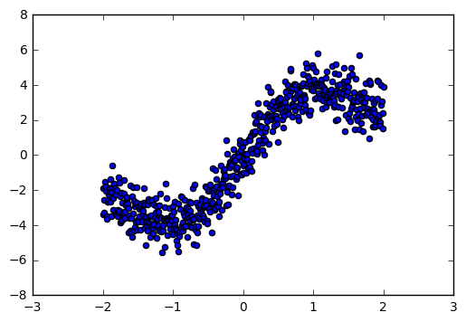

```
4.8941
0.954431
0.808641
0.749761
0.968944
1.13934
1.01932
0.989037
0.955252
0.919323
0.895363
0.874696
0.859704
0.840724
0.826757
0.811704
0.799627
0.799584
0.786348
0.776677
0.768991
0.761451
0.75608
0.756485
0.748079
0.742442
0.738855
0.733743
0.730524
0.727694
```

```python
import numpy as np
import tensorflow as tf
import matplotlib.pyplot as plt

#建立神經層
def add_layer(inputs, in_size, out_size, activation_function=None):
    Weights = tf.Variable(tf.random_normal([in_size, out_size]))
    biases = tf.Variable(tf.zeros([1, out_size]) + 0.1)
    Wx_plus_b = tf.matmul(inputs, Weights) + biases #matrix multiply

    if activation_function is None: #保持線性
        outputs = Wx_plus_b
    else:
        outputs = activation_function(Wx_plus_b)

    return outputs

### Create Data : poly. + noise
x_data = np.linspace(-2,2,600)[:,np.newaxis]
noise = np.random.normal(0,0.8,x_data.shape)#不一定會照著線走
# y_data_ori = 1.5*np.power(x_data,3) + 2*np.power(x_data,2) + 1
y_data_ori = 2*x_data + 2 * np.sin(x_data/0.5)
y_data = y_data_ori + noise

xs = tf.placeholder(tf.float32,[None,1])
ys = tf.placeholder(tf.float32,[None,1])

### Create NN graph
l1 = add_layer(xs, 1,  10, activation_function=tf.nn.relu)
prediction = add_layer(l1 , 10 , 1 , activation_function=None)

# Set Learning Parameter
loss = tf.reduce_mean(tf.reduce_sum(tf.square(y_data - prediction),reduction_indices=[1]))
train_step = tf.train.GradientDescentOptimizer(0.1).minimize(loss)

# initial tensorflow variables
init = tf.global_variables_initializer()

# initial graph
fig = plt.figure()
ax = fig.add_subplot(1,1,1)
ax.scatter(x_data, y_data)
plt.ion()
plt.show()

with tf.Session() as sess:
    sess.run(init)

    for i in range(1500):
        sess.run(train_step, feed_dict={xs:x_data, ys:y_data})

        # predict and plot the result
        if i % 50 ==0:
            print(sess.run(loss,feed_dict={xs:x_data, ys:y_data}))
            try:
                ax.lines.remove(lines[0])
            except Exception:
                pass

            prediction_value = sess.run(prediction, feed_dict={xs: x_data})
            # plot the prediction
            lines = ax.plot(x_data, prediction_value, 'r-', lw=5)
            plt.pause(0.2)

    lines = ax.plot(x_data, y_data_ori,'y-', lw=3)
    plt.pause(30)
```

Tensorboard 1 for graphs

```python
import tensorflow as tf


def add_layer(inputs, in_size, out_size, activation_function=None):
    # add one more layer and return the output of this layer
    with tf.name_scope('layer'):
        with tf.name_scope('weights'):
            Weights = tf.Variable(tf.random_normal([in_size, out_size]), name='W')
        with tf.name_scope('biases'):
            biases = tf.Variable(tf.zeros([1, out_size]) + 0.1, name='b')
        with tf.name_scope('Wx_plus_b'):
            Wx_plus_b = tf.add(tf.matmul(inputs, Weights), biases)
        if activation_function is None:
            outputs = Wx_plus_b
        else:
            outputs = activation_function(Wx_plus_b, )
        return outputs


# define placeholder for inputs to network
with tf.name_scope('inputs'):
    xs = tf.placeholder(tf.float32, [None, 1], name='x_input')
    ys = tf.placeholder(tf.float32, [None, 1], name='y_input')

# add hidden layer
l1 = add_layer(xs, 1, 10, activation_function=tf.nn.relu)
# add output layer
prediction = add_layer(l1, 10, 1, activation_function=None)

# the error between prediciton and real data
with tf.name_scope('loss'):
    loss = tf.reduce_mean(tf.reduce_sum(tf.square(ys - prediction),
                                        reduction_indices=[1]))

with tf.name_scope('train'):
    train_step = tf.train.GradientDescentOptimizer(0.1).minimize(loss)

sess = tf.Session()

# tf.train.SummaryWriter soon be deprecated, use following
writer = tf.summary.FileWriter("/Users/gohuang/Desktop/tensor", sess.graph)

init = tf.global_variables_initializer()
sess.run(init)

# direct to the local dir and run this in terminal:
# $ tensorboard --logdir='/Users/gohuang/Desktop/tensor/'
```

Tensorboard 2 for histograms

```python
import tensorflow as tf
import numpy as np


def add_layer(inputs, in_size, out_size, n_layer, activation_function=None):
    # add one more layer and return the output of this layer
    layer_name = 'layer%s' % n_layer
    with tf.name_scope(layer_name):
        with tf.name_scope('weights'):
            Weights = tf.Variable(tf.random_normal([in_size, out_size]), name='W')
            tf.summary.histogram(layer_name + '/weights', Weights)
        with tf.name_scope('biases'):
            biases = tf.Variable(tf.zeros([1, out_size]) + 0.1, name='b')
            tf.summary.histogram(layer_name + '/biases', biases)
        with tf.name_scope('Wx_plus_b'):
            Wx_plus_b = tf.add(tf.matmul(inputs, Weights), biases)
        if activation_function is None:
            outputs = Wx_plus_b
        else:
            outputs = activation_function(Wx_plus_b, )
        tf.summary.histogram(layer_name + '/outputs', outputs)
    return outputs


# Make up some real data
x_data = np.linspace(-1, 1, 300)[:, np.newaxis]
noise = np.random.normal(0, 0.05, x_data.shape)
y_data = np.square(x_data) - 0.5 + noise

# define placeholder for inputs to network
with tf.name_scope('inputs'):
    xs = tf.placeholder(tf.float32, [None, 1], name='x_input')
    ys = tf.placeholder(tf.float32, [None, 1], name='y_input')

# add hidden layer
l1 = add_layer(xs, 1, 10, n_layer=1, activation_function=tf.nn.relu)
# add output layer
prediction = add_layer(l1, 10, 1, n_layer=2, activation_function=None)

# the error between prediciton and real data
with tf.name_scope('loss'):
    loss = tf.reduce_mean(tf.reduce_sum(tf.square(ys - prediction),
                                        reduction_indices=[1]))
    tf.summary.scalar('loss', loss)

with tf.name_scope('train'):
    train_step = tf.train.GradientDescentOptimizer(0.1).minimize(loss)

sess = tf.Session()
merged = tf.summary.merge_all()

writer = tf.summary.FileWriter("/Users/gohuang/Desktop/tensor", sess.graph)

init = tf.global_variables_initializer()
sess.run(init)

for i in range(1000):
    sess.run(train_step, feed_dict={xs: x_data, ys: y_data})
    if i % 50 == 0:
        result = sess.run(merged,
                          feed_dict={xs: x_data, ys: y_data})
        writer.add_summary(result, i)
```

Classification

手寫辨識:https://www.tensorflow.org/get_started/mnist/beginners  
參考資源：http://terrence.logdown.com/posts/1240896-play-tensorflow-mnist-handwriting-recognition  
$ git clone https://github.com/martin-gorner/tensorflow-mnist-tutorial

[figure not shown]

載入資料、建立layer

```python
import tensorflow as tf
from tensorflow.examples.tutorials.mnist import input_data
# number 1 to 10 data
mnist = input_data.read_data_sets('MNIST_data', one_hot=True)

def add_layer(inputs, in_size, out_size, activation_function=None,):
    # add one more layer and return the output of this layer
    Weights = tf.Variable(tf.random_normal([in_size, out_size]))
    biases = tf.Variable(tf.zeros([1, out_size]) + 0.1,)
    Wx_plus_b = tf.matmul(inputs, Weights) + biases
    if activation_function is None:
        outputs = Wx_plus_b
    else:
        outputs = activation_function(Wx_plus_b,)
    return outputs
```

```
Extracting MNIST_data/train-images-idx3-ubyte.gz
Extracting MNIST_data/train-labels-idx1-ubyte.gz
Extracting MNIST_data/t10k-images-idx3-ubyte.gz
Extracting MNIST_data/t10k-labels-idx1-ubyte.gz
```

定義正確率function

```python
def compute_accuracy(v_xs, v_ys):
    global prediction
    y_pre = sess.run(prediction, feed_dict={xs: v_xs})
    #每個位置都會有個預測值 最大值就是預測的結果
    #比較和真實答案是否相同
    correct_prediction = tf.equal(tf.argmax(y_pre,1), tf.argmax(v_ys,1))
    accuracy = tf.reduce_mean(tf.cast(correct_prediction, tf.float32))
    result = sess.run(accuracy, feed_dict={xs: v_xs, ys: v_ys})
    return result
```

使用softmax（logistic的多維版本）  
[0:30%, 1:30%, 2:40%,...]

```python
# define placeholder for inputs to network
xs = tf.placeholder(tf.float32, [None, 784]) # 28x28
ys = tf.placeholder(tf.float32, [None, 10]) # 1-10

# add output layer
prediction = add_layer(xs, 784, 10,  activation_function=tf.nn.softmax) #softmax

# the error between prediction and real data
cross_entropy = tf.reduce_mean(-tf.reduce_sum(ys * tf.log(prediction),
                                              reduction_indices=[1]))       # loss
train_step = tf.train.GradientDescentOptimizer(0.5).minimize(cross_entropy)

sess = tf.Session()

init = tf.global_variables_initializer()
sess.run(init)

for i in range(1000):
    batch_xs, batch_ys = mnist.train.next_batch(100)
    sess.run(train_step, feed_dict={xs: batch_xs, ys: batch_ys})
    if i % 50 == 0:
        print(compute_accuracy(
            mnist.test.images, mnist.test.labels))
```

[output not shown]

Overfiting & Dropout

何謂overfiting?

[figure not shown]

Overfiting 解法：

- To be big data (Data augmentation).
- Reduce features to reduce the parameter space.
- Early stop (training) or cut/prune tree depth (decision tree), etc.
- Add regularization (L2 or L1 penalty).

[figure not shown]

延伸閱讀：https://allenlu2007.wordpress.com/2016/05/14/overfit-%E8%A9%AE%E9%87%8B/

Tensorflow 中的 Overfiting： 用Dropout regularization解決  
訓練時隨機忽略神經元和連結，使得不完整，讓預測的結果不會過度的依賴某些神經元

原本的神經網路

[figure not shown]

Dropout的神經網路

[figure not shown]

資料來源：https://read01.com/eMLNP7.html